# Assignment 2

Garima Sharma

November 9, 2015

Assignment 2

Question 1

To read rocket propellent data, I have used read.delim().

```r
rm(list=ls())
rocketdata <- read.delim("C:/Garima/2nd Flex/DAM/Week 2/Data-ex-2-1 (Rocket Prop).txt",h=T)
rocketdata
```

```
##          y     x
## 1  2158.70 15.50
## 2  1678.15 23.75
## 3  2316.00  8.00
## 4  2061.30 17.00
## 5  2207.50  5.50
## 6  1708.30 19.00
## 7  1784.70 24.00
## 8  2575.00  2.50
## 9  2357.90  7.50
## 10 2256.70 11.00
## 11 2165.20 13.00
## 12 2399.55  3.75
## 13 1779.80 25.00
## 14 2336.75  9.75
## 15 1765.30 22.00
## 16 2053.50 18.00
## 17 2414.40  6.00
## 18 2200.50 12.50
## 19 2654.20  2.00
## 20 1753.70 21.50
```

Question 2

I have plotted the rocket propellant data as follows:

```r
names(rocketdata)
```

```
## [1] "y" "x"
```

```r
print(rocketdata)
```

```
##          y     x
## 1  2158.70 15.50
## 2  1678.15 23.75
## 3  2316.00  8.00
## 4  2061.30 17.00
## 5  2207.50  5.50
## 6  1708.30 19.00
## 7  1784.70 24.00
## 8  2575.00  2.50
## 9  2357.90  7.50
## 10 2256.70 11.00
## 11 2165.20 13.00
## 12 2399.55  3.75
## 13 1779.80 25.00
## 14 2336.75  9.75
## 15 1765.30 22.00
## 16 2053.50 18.00
## 17 2414.40  6.00
## 18 2200.50 12.50
## 19 2654.20  2.00
## 20 1753.70 21.50
```

```r
n=dim(rocketdata)[1]
```

[figure not shown]

Question 3

I have performed linear regression without using lm in the following manner:

3.1

```r
meanx = mean(rocketdata$x)
meany = mean(rocketdata$y)
Sxx=sum((rocketdata$x-meanx)^2)
Sxy=sum((rocketdata$x-meanx)*rocketdata$y)
```

Value of Sxx is 1106.559375 and value of Sxy is -4.111265410^{4} .

3.2

```r
beta1 = Sxy / Sxx
beta1
```

```
## [1] -37.15359
```

```r
beta0 = meany - beta1*meanx
beta0
```

```
## [1] 2627.822
```

3.3

```r
SST = sum((rocketdata$y - meany)^2)
SST
```

```
## [1] 1693738
```

```r
yrocketdata = beta1 * rocketdata$x + beta0
yrocketdata
```

```
##  [1] 2051.942 1745.425 2330.594 1996.211 2423.478 1921.904 1736.136
##  [8] 2534.938 2349.170 2219.133 2144.826 2488.496 1698.983 2265.575
## [15] 1810.443 1959.058 2404.901 2163.402 2553.515 1829.020
```

```r
SSR = sum((yrocketdata - meany)^2)
SSR
```

```
## [1] 1527483
```

```r
SSRES = sum((rocketdata$y - yrocketdata)^2)
SSRES
```

```
## [1] 166254.9
```

Value of SST is 1.693737610^{6}, value of SSR is 1.527482710^{6} and value of SSRES is 1.662548610^{5}.

3.4

```r
rocketdataRsquare = SSR / SST
```

Value of R^2 is 0.9018414.

Question 4

I have used the following method to calculate linear regression using lm().

4.1

```r
modelrocketdata = lm(y ~ x, data=rocketdata)

sxxnew=sum((rocketdata$x-meanx)^2)
sxynew=sum((rocketdata$x-meanx)*rocketdata$y)
```

Value of Sxx is 1106.559375 and value of Sxy is -4.111265410^{4} .

4.2

```r
beta0new = modelrocketdata$coefficients[1]
beta1new = modelrocketdata$coefficients[2]
```

Value of $\beta0$ is 2627.822359 and value of $\beta1$ is -37.1535909.

4.3

```r
sstnew = sum((rocketdata$y - meany)^2)
ssrnew = sum((modelrocketdata$fitted.values - meany)^2)
ssresnew = sum((rocketdata$y - modelrocketdata$fitted.values)^2)
```

Value of SST is 1.693737610^{6}, value of SSR is 1.527482710^{6} and value of SSRES is 1.662548610^{5}.

4.4

```r
rocketdataRsquarenew = summary(modelrocketdata)$r.square
```

Value of R^2 is 0.9018414.

Question 5

Hypothesis Testing and Interval Estimation

5.1 t Test

t-statistic is calculated as $t0 = \beta1 / SE(\beta1)$

t-statistic can be calculated using summary of data read from the text file above and calculating linear regression.

```r
modelrocketdata = lm(y ~ x, data=rocketdata)
summary(modelrocketdata)$coef
```

```
##               Estimate Std. Error   t value     Pr(>|t|)
## (Intercept) 2627.82236  44.183912  59.47464 4.063559e-22
## x            -37.15359   2.889107 -12.85989 1.643344e-10
```

```r
tvalue = summary(modelrocketdata)$coef[,1]/summary(modelrocketdata)$coef[,2]
tcritical = qt(1-(0.05/2), 18)
```

t-statistic calculated is 59.4746425, -12.8598895.

Assuming alpha as 0.05, t critical can be calculated as 2.100922.

I can conclude that there exists a linear relationship between y and x.

Using p-value as calculated below which is also obtainable from summary data,

```r
pval = 2*(1-pt(abs(summary(modelrocketdata)$coef[,1]/summary(modelrocketdata)$coef[,2]),18))
```

Since, pvalue of 0, 1.643343210^{-10} is less than the value of 0.05, we can reject the null hypothesis.

5.2 ANOVA Test

```r
MSRES=SSRES/(n-2)
fvalue = round((SSR/1)/(SSRES/(n-2)),2)
```

```r
n=20
alpha = 0.05
anova(modelrocketdata)
```

```
## Analysis of Variance Table
##
## Response: y
##           Df  Sum Sq Mean Sq F value    Pr(>F)
## x          1 1527483 1527483  165.38 1.643e-10 ***
## Residuals 18  166255    9236
## ---
## Signif. codes:  0 '***' 0.001 '**' 0.01 '*' 0.05 '.' 0.1 ' ' 1
```

```r
F0 = round((SSR/1)/(SSRES/(n-2)),2)
crticalf = qf(1-alpha,1,n-2)
```

Value of F0 is 165.38 which can also be calculated from anova method. value of fcritical is 4.4138734.

Comparing the value of F statistic which is greater than the F critical, we can conclude that null hypothesis can be rejected. Hence there is a linear relationship between y and x.

F test p-value is `1-pf(fvalue, 1, 18)`.

p-value is 1.643081210^{-10}

Since p-value is less than the value of alpha 0.05, we can reject the null hypothesis.

5.3 Calculating Confidence Interval

5.3.1 I am calculating confidence interval for coefficients by using the following formulas for slope as well as intercept:

```r
alpha = 0.05
n=20
modelrocketdata = lm(y ~ x, data=rocketdata)
beta0hat = modelrocketdata$coefficients[1]
beta1hat = modelrocketdata$coefficients[2]
tcritical = qt(1-alpha/2, n-2)
sebeta0hat = summary(modelrocketdata)$coef[1,2]
sebeta1hat = summary(modelrocketdata)$coef[2,2]
```

Confidence Interval at 95% level of significance

For $\beta0$, 2534.995 <= $\beta0$ <= 2720.649

For $\beta1$, -43.223 <= $\beta1$ <= -31.084

5.3.2 Calculating for fitted values,

I calculated the fitted values and confidence interval of y by using the given value of x as mentioned below:

5.3.3 We can calculate predicted value as:

[output not shown]

[output cut: 27 more lines]

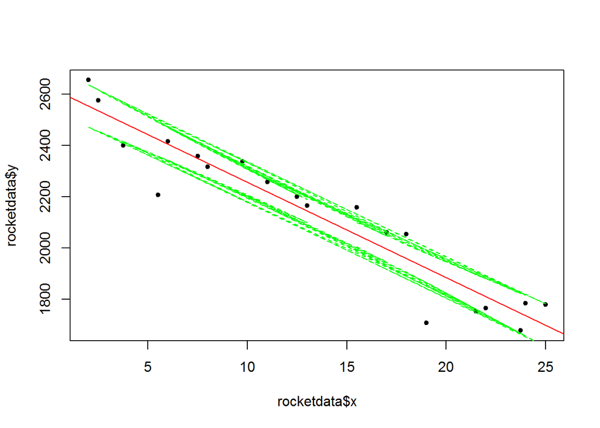

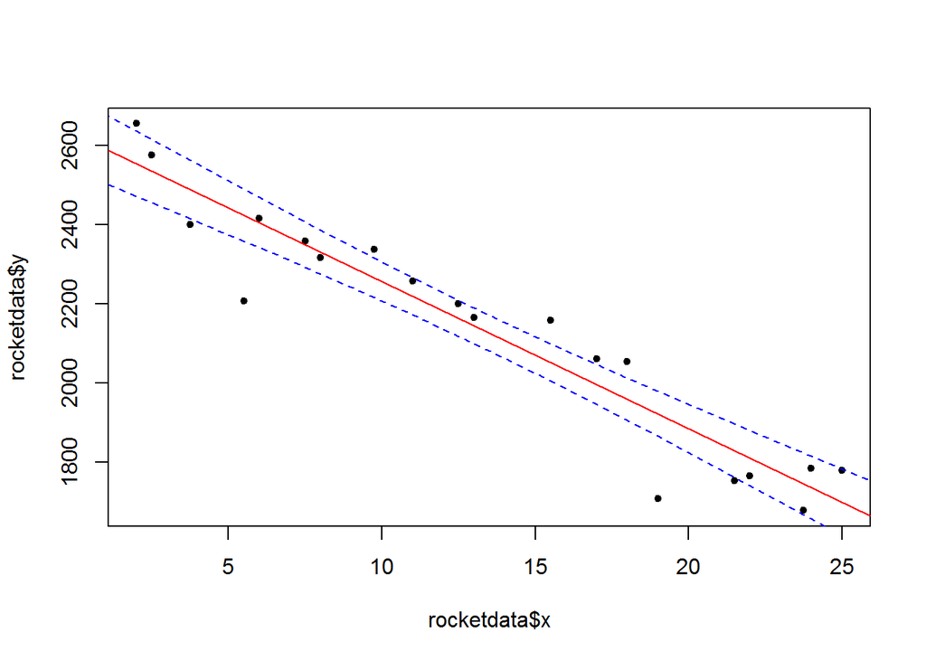